# Project2 (1)

## L2 Regularization on Neural Network (Reduce Overfit)

Adding penalty term to used to further prevent the overfit happening with our Nurual Network to improve Validation Accuracy Score. It's controlled by a hyperparameter and the idea is to be able to have a balance to fit the complexity, so I'm hoping to do that here

```python
from tensorflow.keras import regularizers

##L2 regularization. And I actualy got this idea while studying for Quiz 1. M4.10 Lasso (15:54) and I remember reading it in a book for CIS 412 class, don't know where.

model = Sequential([
    layers.InputLayer(input_shape=(50,)),
    layers.Dense(128, activation='relu', kernel_regularizer=regularizers.l2(0.001)),
    layers.Dense(64, activation='relu', kernel_regularizer=regularizers.l2(0.001)),
    layers.Dense(10, activation='softmax')
])

#Compile the model
model.compile(optimizer=Adam(learning_rate=0.001),
              loss='sparse_categorical_crossentropy',
              metrics=['accuracy'])

#Early stopping
early_stopping = EarlyStopping(monitor='val_loss', patience=5, restore_best_weights=True)

#Train the model
history = model.fit(
    x=X_train_pca,
    y=y_train_pca,
    epochs=100,
    batch_size=32,
    validation_data=(X_val_pca, y_val_pca),
    callbacks=[early_stopping],
    verbose=1
)
```

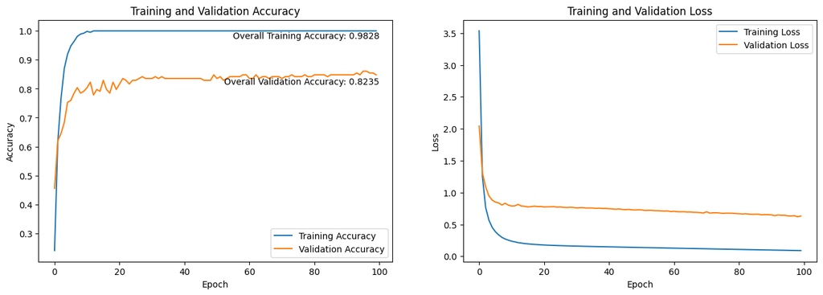

```python
import matplotlib.pyplot as plt

#Here I am calulating overall training and val accuracy. I got this code from HW 2 and Project 2 Example to help me.
overall_train_accuracy = sum(history.history['accuracy']) / len(history.history['accuracy'])
overall_val_accuracy = sum(history.history['val_accuracy']) / len(history.history['val_accuracy'])


plt.figure(figsize=(16, 5))

#accuracy
plt.subplot(1, 2, 1)
plt.plot(history.history['accuracy'], label='Training Accuracy')
plt.plot(history.history['val_accuracy'], label='Validation Accuracy')
plt.title('Training and Validation Accuracy')
plt.xlabel('Epoch')
plt.ylabel('Accuracy')
plt.legend()
#This is my  overall accuracy to the side of the plot
plt.text(len(history.history['accuracy']), overall_train_accuracy, f'Overall Training Accuracy: {overall_train_accuracy:.4f}', ha='right', va='center')
plt.text(len(history.history['val_accuracy']), overall_val_accuracy, f'Overall Validation Accuracy: {overall_val_accuracy:.4f}', ha='right', va='center')

#This is training and validation loss
plt.subplot(1, 2, 2)
plt.plot(history.history['loss'], label='Training Loss')
plt.plot(history.history['val_loss'], label='Validation Loss')
plt.title('Training and Validation Loss')
plt.xlabel('Epoch')
plt.ylabel('Loss')
plt.legend()

plt.show()
```

```python
print(f'Overall Training Accuracy: {overall_train_accuracy:.3f}')
print(f'Overall Validation Accuracy: {overall_val_accuracy:.3f}')
```

```
Overall Training Accuracy: 0.983
Overall Validation Accuracy: 0.824
```

## Conclusions

Classifers alone would not performed well with an siholoutte score closer to 0 than 1, and had if I added more than 10 clusters it would've make the entire project more complex and difficult to pin down. Because this is my first time using images, I did go a semi-safe route in terms of complexity/variation of the model so I had a fair chance of working it in two weeks.

In conslusion, my supervised learning and L2 regularization generated good results. I really enjoyed learning something new I've never done before. I plan on using these ML techiques more frequently, and I would be interested in seeing how this applies to more dirty data!